# Google Play Store Project

Christopher Han

December 7, 2018

# Introduction

The android platform, first released in 2008 by Google, is now home to more than 2.6 million applications available on the Google Play Store. From the millions of applications out there, how do consumers choose which application to use and what does it mean for businesses? In this project, we examine a sample of approximately 10,000 applications on Google Play Store in hopes of finding variables that are significant in predicting the application’s success. For the purpose of this analysis, we define the application’s success to be its rating on a scale of 1 to 5, with 5 being the highest.

The dataset used is from [Kaggle](https://www.kaggle.com/lava18/google-play-store-apps#googleplaystore.csv). The original data was collected by web-scraping from the Google Play Store by the user Lavanya Gupta.

## Getting started

Here we load all the packages needed as well as bring in the cleandata function from cleandata.R.

```r
#install.packages("devtools") #if needed
#devtools::install_github("MichaelJMahometa/SDSRegressionR", force = TRUE)
library(dplyr)
library(lubridate)
library(car)
library(SDSRegressionR)
library(splines)
library(boot)

source("cleandata.R")
```

## Data cleaning and formatting

```r
googleData <- read.csv("googleplaystore.csv", stringsAsFactors = FALSE)
googleData <- cleandata(googleData)
```

The original data contains 10841 observations with 12 predictors and one response. Out of the 10841 observations, 9660 were unique (by application name).

- Predictors
  - App
  - Category
  - Reviews
  - Size
  - Installs
  - Type
  - Price
  - Content.Rating
  - Genres
  - Last.Updated
  - Current.Ver
  - Android.Ver

The data was fairly clean to begin with, with only minor adjustments to be made. First of all, the variable names were adjusted to remove “.” and to be in lower case. Then, we examined the rows to identify any rows with missing values in the ‘rating’ column and subsequently removed them. As we will see later, there are other columns with missing data as well but we handle those differently since they are not the response variable like ‘rating’; therefore, it’s not a fatal error and we work around it.

It is worth noting that there was one “bad” row with data shifted to the right due to a missing value in one of the columns. We removed that row and subsequently had to reformat the column types since that one row caused some columns to have incorrect structure (e.g character in place of numeric).

Moreover, the columns ‘genres’, ‘currentver’ and ‘app’ were removed. The variable ‘genres’ heavily overlapped with ‘category’ and provided very little additional information. The variable ‘currentver’ varied too much since different applications used different scale to communicate their current version (e.g 1.101 vs. Y4W-GATE_CS-5.0.0). Furthermore, more than 10% of the values for ‘currentver’ were ‘Varies with device’ which essentially means that it’s not available. The variable ‘app’ which contained the application name was also removed because the name is irrelevant for this analysis.

A quick look at the cleaned data

```
##         category rating reviews size    installs type price contentrating
## 1 ART_AND_DESIGN    4.1     159 19.0     10,000+ Free     0      Everyone
## 2 ART_AND_DESIGN    3.9     967 14.0    500,000+ Free     0      Everyone
## 3 ART_AND_DESIGN    4.7   87510  8.7  5,000,000+ Free     0      Everyone
## 4 ART_AND_DESIGN    4.5  215644 25.0 50,000,000+ Free     0          Teen
## 5 ART_AND_DESIGN    4.3     967  2.8    100,000+ Free     0      Everyone
## 6 ART_AND_DESIGN    4.4     167  5.6     50,000+ Free     0      Everyone
##   lastupdated androidver
## 1  2018-01-07        3.9
## 2  2018-01-15        3.9
## 3  2018-08-01        3.9
## 4  2018-06-08        4.2
## 5  2018-06-20        4.4
## 6  2017-03-26        2.3
```

## Initial look at the variables

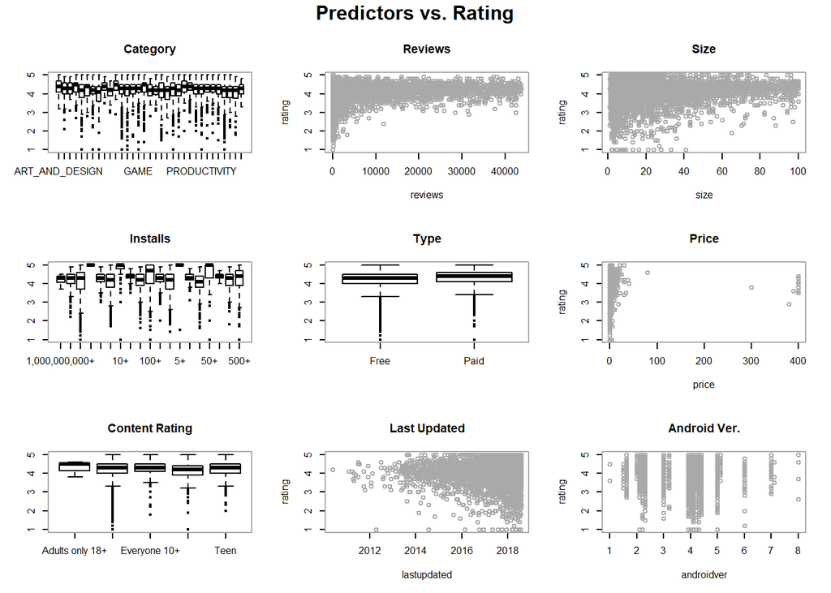

As we can see here, the quantitative predictors such as reviews, size and price are quite concentrated on the left of the scale. This makes sense since out of ~8000 applications, most are free, small in size, and fairly new or unpopular hence the small number of reviews. In contrast, the predictor lastupdated is quite concentrated to the right, which also makes sense since developers are constantly updating their applications. The skew of some predictors here are quite interesting and we will look more at those later.

## Linear model

```r
fullmodel <- lm(rating~ ., data = googleData)
#summary(fullmodel)
Anova(fullmodel, type = "III")
```

```
## Anova Table (Type III tests)
##
## Response: rating
##                Sum Sq   Df F value    Pr(>F)
## (Intercept)      3.12    1 11.8459 0.0005808 ***
## category        58.23   32  6.9035 < 2.2e-16 ***
## reviews          1.12    1  4.2586 0.0390837 *
## size             0.72    1  2.7462 0.0975274 .
## installs        90.85   18 19.1491 < 2.2e-16 ***
## type            13.66    1 51.8102 6.658e-13 ***
## price            1.89    1  7.1866 0.0073599 **
## contentrating    0.30    4  0.2807 0.8906131
## lastupdated     24.84    1 94.2257 < 2.2e-16 ***
## androidver       0.86    1  3.2447 0.0716908 .
## Residuals     2143.92 8134
## ---
## Signif. codes:  0 '***' 0.001 '**' 0.01 '*' 0.05 '.' 0.1 ' ' 1
```

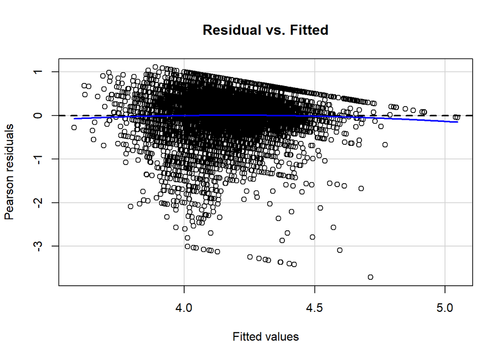

```r
residualPlot(fullmodel, main = "Residual vs. Fitted")
```

## Calculate MSE

To calculate the test error of a linear model, two methods were used that are very similar. First one is a basic approach that involves using two-thirds of the data for training and one-third of the test to calculate the MSE. Second one is a 10-fold cross validation with 5 iterations to calculate the MSE 5 times; afterwards, the average was calculated.

```
##       MSE   c.v MSE
## 0.2674601 0.2662772
```

The cross validated test error is around 26.6% for the linear model. It is worth mentioning that not all assumptions are met to run the linear regression.

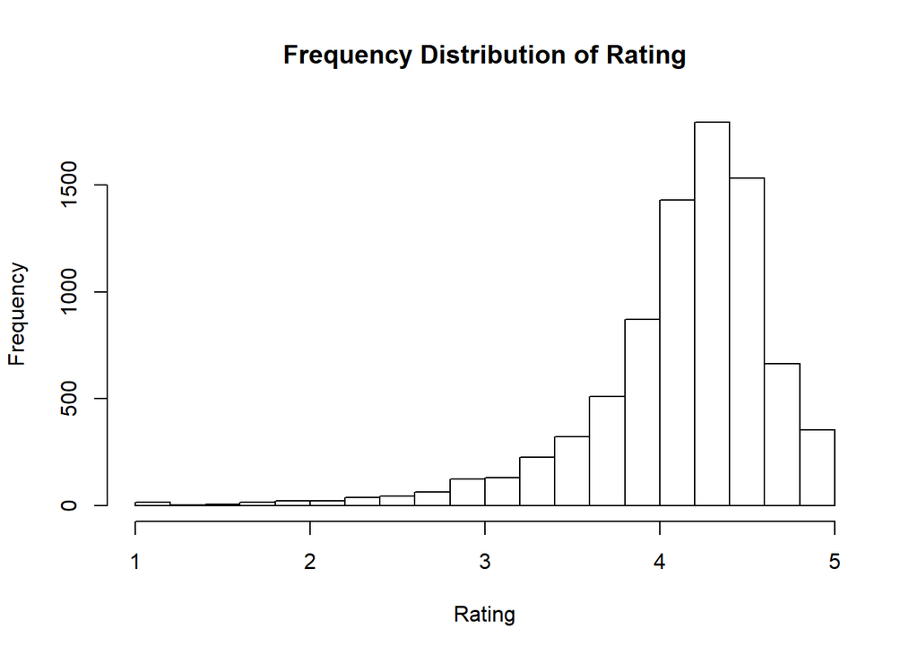

As we can see, the response variable is not distributed normally, rather it’s negatively skewed.

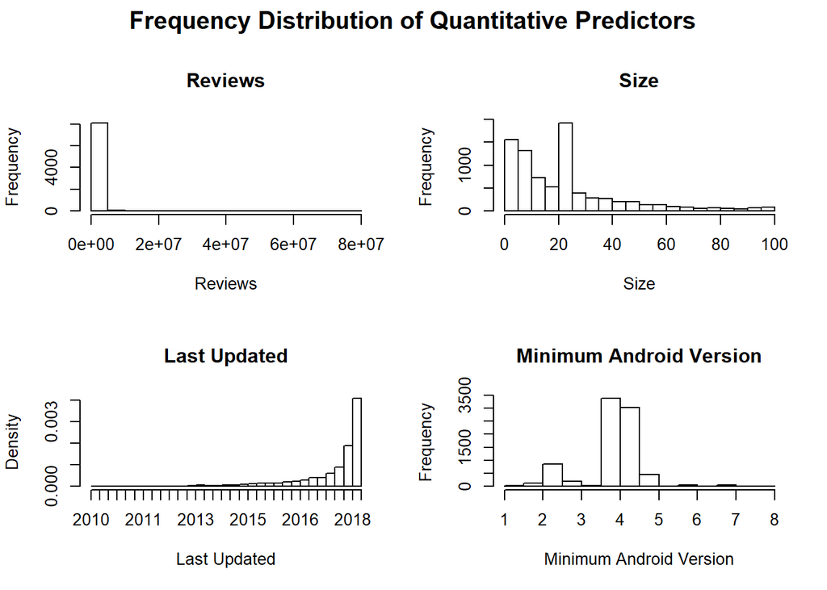

The predictors ‘reviews’ and ‘size’ are positively skewed whereas ‘last updated’ is negatively skewed. The minimum android version seems to be the most normally distributed here out of the plots we looked at so far.

## Variables that are possibly correlated

When we start to analyze the meaning of the predictors more in depth, we realize that there are possible correlations between some of the variables. For example, as the number of installs increases, naturally one would expect the number of reviews to increase as well. Another correlation, possibly more obvious, would be between type of the application (free or paid) and price. In the next two sections, we run some tests to see if the pair of predictors in question have a significant relationship and if so, whether it is acceptable to remove one.

### Reviews and Installs

In the initial linear model, ‘reviews’ and ‘installs’ were both significant predictors of rating. However, there seems to be a relationship between the two if we think of user behavior. Naturally, we expect users to leave reviews for the applications they download. Therefore, the more installs there are, the more reviews there should be. This relationship is tested through a simple linear model.

```r
summary(lm(reviews~ installs, data= googleData))$r.squared
```

```
## [1] 0.412293
```

```r
Anova(lm(reviews~ installs, data= googleData), type = "III")
```

```
## Anova Table (Type III tests)
##
## Response: reviews
##                 Sum Sq   Df F value    Pr(>F)
## (Intercept) 8.0091e+15    1 3448.54 < 2.2e-16 ***
## installs    1.3321e+16   18  318.65 < 2.2e-16 ***
## Residuals   1.8988e+16 8176
## ---
## Signif. codes:  0 '***' 0.001 '**' 0.01 '*' 0.05 '.' 0.1 ' ' 1
```

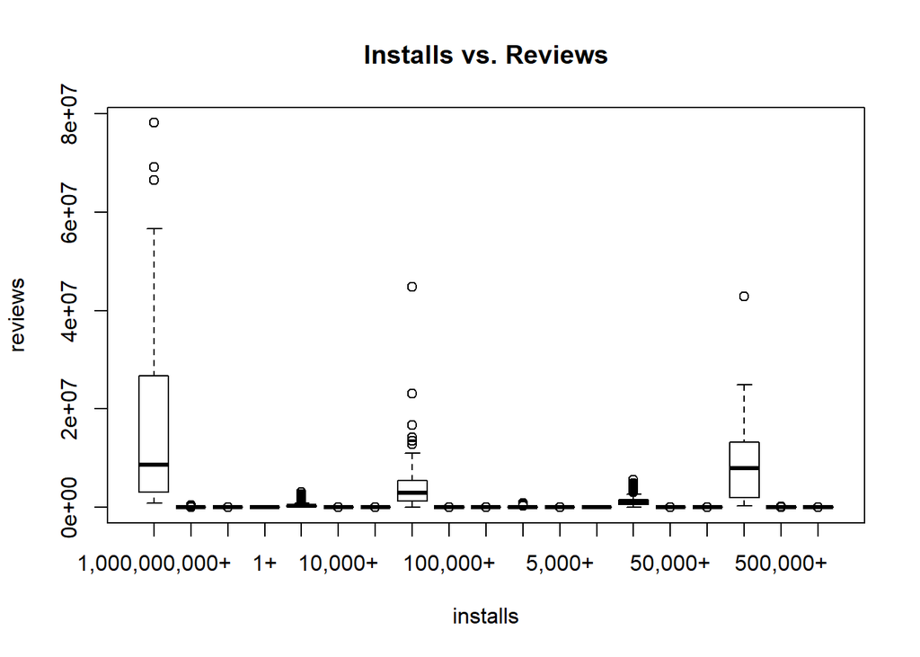

```r
plot(reviews~ installs, data = googleData, main = "Installs vs. Reviews")
```

As we can see in the summary, installs can account for 41.23% of the variation in reviews. The Anova test also tells us that the relationship is significant. Lastly, we can confirm visually with the plot that the applications with the highest number of installs show distributions with higher mean.

### Type and Price

We also suspect that type and price carry similar information since type and price are also inherently related. First, let’s check the number of free applications vs paid applications in our data.

```r
onlypaid <- googleData[googleData$price != 0,]
dim(onlypaid)
```

```
## [1] 604  10
```

There are only 604 observations out of 8195 that are paid applications, about 7% of the data. Clearly, there are way more free applications (although many have in-app purchases) than paid applications in the Google Play Store.

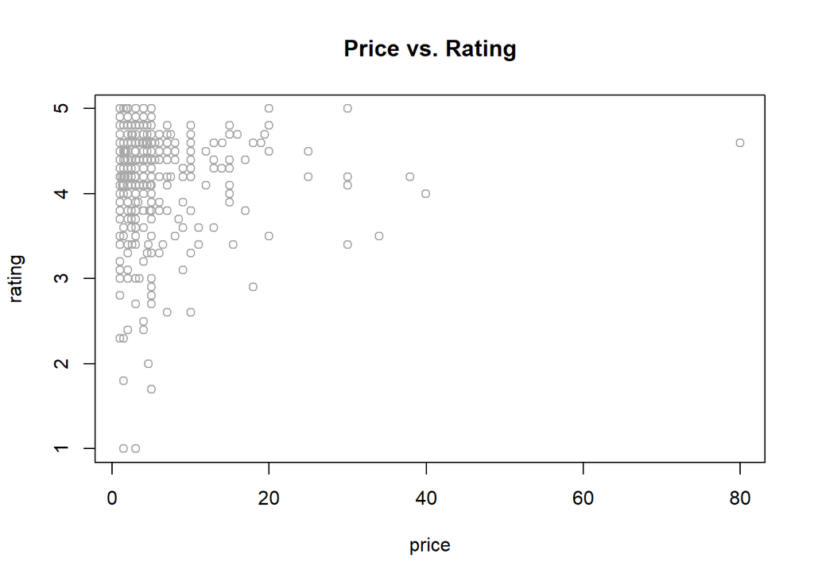

Even after removing the extremes (the free and highly expensive applications), the data is heavily concentrated to the left. This makes sense since most applications are priced at $0.99, $1.99, or a similar price to attract users.

As practice, polynomials, splines, and local regression were used to model the data.

### Polynomials, Splines, Local Regression (Non-linear)

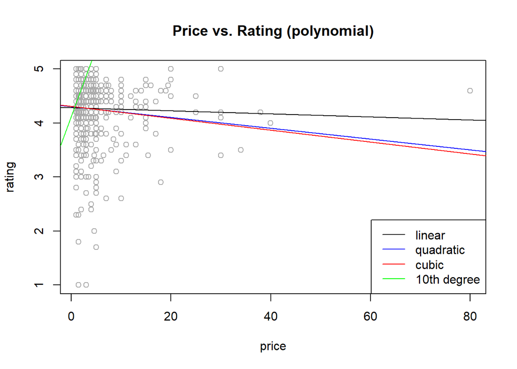

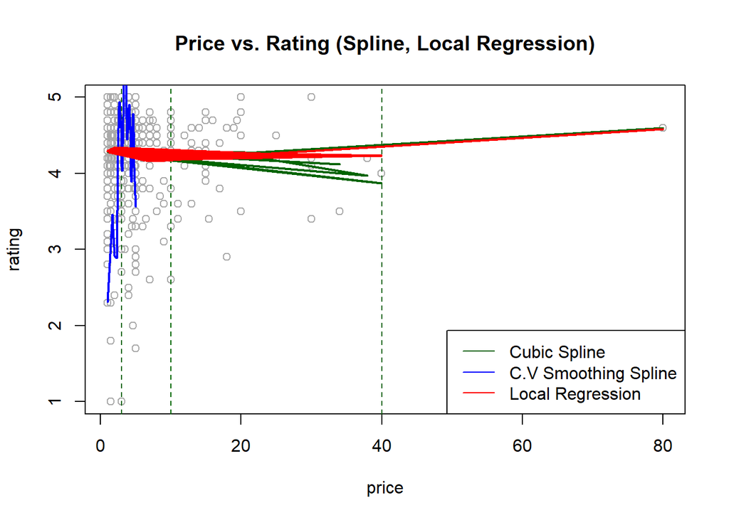

## Backward Subset Selection

Since we identified two pairs of predictors with significant relationships, a backward subsect selection seems appropriate to test whether removing one of the two would hurt the overall performance of the model. First, we removed the predictor ‘price’ and compared it with the full model. After testing few different models, we decided on the alpha level of 0.001. With the alpha level of 0.001, the model without ‘price’ and the model without ‘reviews’ does not lose a significant amount of variance. As we can see below, removing both predictors does not significantly decrease the R squared.

```r
updatedmodel <- lm(rating~. - price - reviews, data = googleData)
summary(updatedmodel)$r.squared
```

```
## [1] 0.09023483
```

```r
Anova(updatedmodel, type = "III")
```

```
## Anova Table (Type III tests)
##
## Response: rating
##                Sum Sq   Df F value    Pr(>F)
## (Intercept)      3.96    1 15.0010 0.0001083 ***
## category        58.67   32  6.9475 < 2.2e-16 ***
## size             0.60    1  2.2892 0.1303133
## installs        94.69   18 19.9347 < 2.2e-16 ***
## type            12.06    1 45.6984 1.475e-11 ***
## contentrating    0.31    4  0.2916 0.8836105
## lastupdated     24.61    1 93.2479 < 2.2e-16 ***
## androidver       0.91    1  3.4470 0.0634015 .
## Residuals     2146.93 8136
## ---
## Signif. codes:  0 '***' 0.001 '**' 0.01 '*' 0.05 '.' 0.1 ' ' 1
```

Size and content rating are two predictors that are not significant and we removed them. Again, the R squared stayed relatively the same.

```r
anova(fullmodel, updatedmodel, updatedmodel2)
```

```
## Analysis of Variance Table
##
## Model 1: rating ~ category + reviews + size + installs + type + price +
##     contentrating + lastupdated + androidver
## Model 2: rating ~ (category + reviews + size + installs + type + price +
##     contentrating + lastupdated + androidver) - price - reviews
## Model 3: rating ~ (category + reviews + size + installs + type + price +
##     contentrating + lastupdated + androidver) - price - reviews -
##     size - contentrating
##   Res.Df    RSS Df Sum of Sq      F   Pr(>F)
## 1   8134 2143.9
## 2   8136 2146.9 -2  -3.01296 5.7156 0.003308 **
## 3   8141 2147.8 -5  -0.89823 0.6816 0.637383
## ---
## Signif. codes:  0 '***' 0.001 '**' 0.01 '*' 0.05 '.' 0.1 ' ' 1
```

```
##       MSE   c.v MSE
## 0.2678872 0.2663938
```

## Second look at the response variable

Earlier, it was mentioned that the response variable ‘rating’ is not normally distributed, but rather negatively skewed. Several attempts at transformation were made such as square, square root, and log, none of which affected the skew significantly.

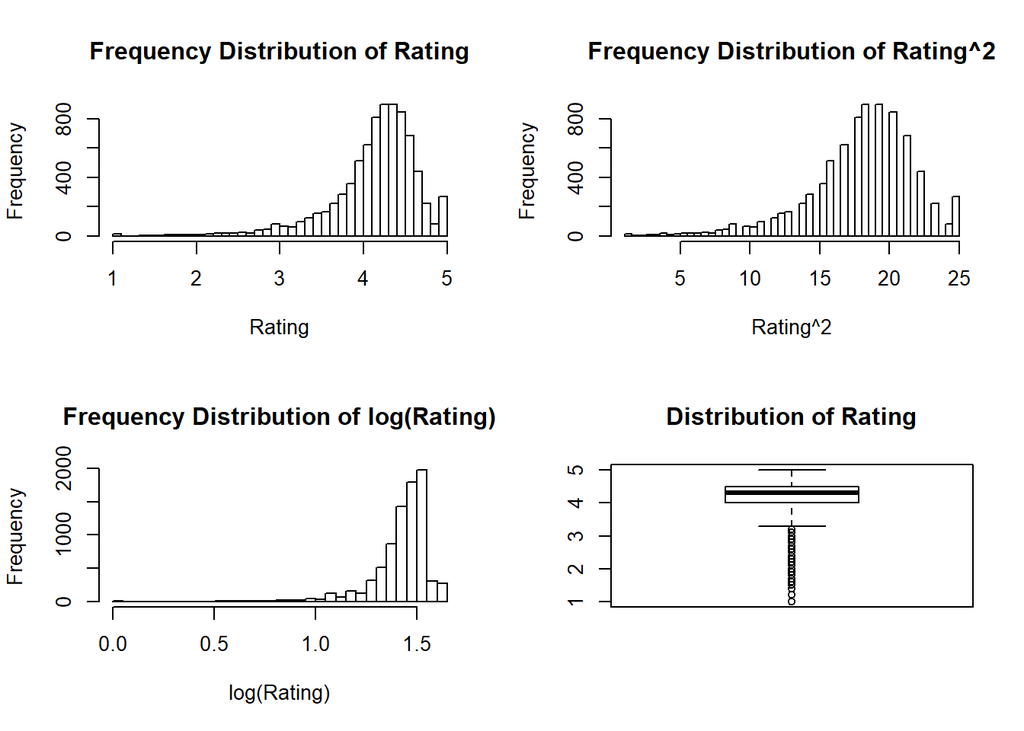

```
##    Min. 1st Qu.  Median    Mean 3rd Qu.    Max.
##   1.000   4.000   4.300   4.173   4.500   5.000
```

From the summary, we see that 25% of the data has ratings from 1.0 to 4.0 where as 75% of the data has ratings from 4.0 to 5.0. This matches perfectly with what we see in the histogram. Hence, perhaps the model performs differently if we divide the data into two: low ratings (1.0 - 4.0) and high ratings (4.0 - 5.0).

```r
lowrating <- filter(newData, rating < 4)
highrating <- filter(newData, rating >=4)
```

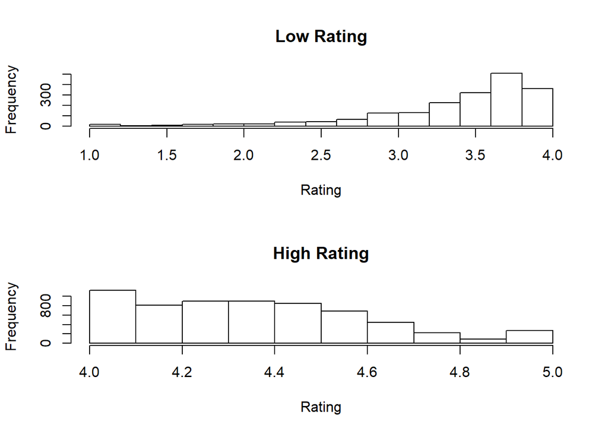

Subsetting the data into two based on the rating slightly helps the normality. When a linear model was fit, the R squared increased to 20.22% for both low rating and high rating.

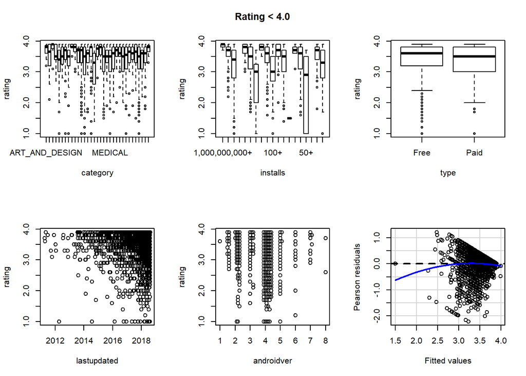

[figure not shown]

# Conclusion

In this project, we aimed to identify which predictors are significant in predicting the rating of an application in the Google Play Store. The methods used were linear regression, backward subset selection, cross validation calculation of test error, nonlinear fits such as polynomials, splines, and local regression.

Out of the initial 12 variables, only 4 were deemed significant with an alpha level of 0.001: category, number of installs, free or paid, and the last updated date. Some of the categories with the highest average rating were entertainment (4.44), dating (4.36) and beauty (4.34). In contrast, as the number of installs went up, the average rating seemed to decrease. Paid applications received better rating than free applications on average (4.26 vs. 4.17). Furthermore, if the application is more recently updated, it is more likely to have a higher rating.

One big limitation of this analysis is that the data is not distributed evenly and most variables are heavily skewed. For this reason, the only reliable predictors of rating that is not heavily influenced by the skew would be the category and the number of installs. If you are a new application developer, it may make sense to explore the entertainment, dating, or beauty categories if you want to achieve the higher rating. However, as your application gets more popular, it is natural for the rating to decrease.

Lastly, although we defined the rating to be the measure of an application’s success, one could argue that the number of installs is a better indicator. Another important measure would be the revenue that an application generates. In the future, it would be interesting to develop models that would predict other measures of success such as the ones mentioned earlier.